# Analysis of Red Wine Data Set by Vamshi

Packages used in this analysis are listed below:

```r
library(gridExtra)
library(ggplot2)
library(GGally)
library(ggcorrplot)
```

# Univariate Plot Section

### Structure of data

```
## 'data.frame':    1599 obs. of  13 variables:
##  $ X                   : int  1 2 3 4 5 6 7 8 9 10 ...
##  $ fixed.acidity       : num  7.4 7.8 7.8 11.2 7.4 7.4 7.9 7.3 7.8 7.5 ...
##  $ volatile.acidity    : num  0.7 0.88 0.76 0.28 0.7 0.66 0.6 0.65 0.58 0.5 ...
##  $ citric.acid         : num  0 0 0.04 0.56 0 0 0.06 0 0.02 0.36 ...
##  $ residual.sugar      : num  1.9 2.6 2.3 1.9 1.9 1.8 1.6 1.2 2 6.1 ...
##  $ chlorides           : num  0.076 0.098 0.092 0.075 0.076 0.075 0.069 0.065 0.073 0.071 ...
##  $ free.sulfur.dioxide : num  11 25 15 17 11 13 15 15 9 17 ...
##  $ total.sulfur.dioxide: num  34 67 54 60 34 40 59 21 18 102 ...
##  $ density             : num  0.998 0.997 0.997 0.998 0.998 ...
##  $ pH                  : num  3.51 3.2 3.26 3.16 3.51 3.51 3.3 3.39 3.36 3.35 ...
##  $ sulphates           : num  0.56 0.68 0.65 0.58 0.56 0.56 0.46 0.47 0.57 0.8 ...
##  $ alcohol             : num  9.4 9.8 9.8 9.8 9.4 9.4 9.4 10 9.5 10.5 ...
##  $ quality             : int  5 5 5 6 5 5 5 7 7 5 ...
```

The dataset contains 13 variables and 1599 observations.

### Summary of data file:

```
##        X          fixed.acidity   volatile.acidity  citric.acid
##  Min.   :   1.0   Min.   : 4.60   Min.   :0.1200   Min.   :0.000
##  1st Qu.: 400.5   1st Qu.: 7.10   1st Qu.:0.3900   1st Qu.:0.090
##  Median : 800.0   Median : 7.90   Median :0.5200   Median :0.260
##  Mean   : 800.0   Mean   : 8.32   Mean   :0.5278   Mean   :0.271
##  3rd Qu.:1199.5   3rd Qu.: 9.20   3rd Qu.:0.6400   3rd Qu.:0.420
##  Max.   :1599.0   Max.   :15.90   Max.   :1.5800   Max.   :1.000
##  residual.sugar     chlorides       free.sulfur.dioxide
##  Min.   : 0.900   Min.   :0.01200   Min.   : 1.00
##  1st Qu.: 1.900   1st Qu.:0.07000   1st Qu.: 7.00
##  Median : 2.200   Median :0.07900   Median :14.00
##  Mean   : 2.539   Mean   :0.08747   Mean   :15.87
##  3rd Qu.: 2.600   3rd Qu.:0.09000   3rd Qu.:21.00
##  Max.   :15.500   Max.   :0.61100   Max.   :72.00
##  total.sulfur.dioxide    density             pH          sulphates
##  Min.   :  6.00       Min.   :0.9901   Min.   :2.740   Min.   :0.3300
##  1st Qu.: 22.00       1st Qu.:0.9956   1st Qu.:3.210   1st Qu.:0.5500
##  Median : 38.00       Median :0.9968   Median :3.310   Median :0.6200
##  Mean   : 46.47       Mean   :0.9967   Mean   :3.311   Mean   :0.6581
##  3rd Qu.: 62.00       3rd Qu.:0.9978   3rd Qu.:3.400   3rd Qu.:0.7300
##  Max.   :289.00       Max.   :1.0037   Max.   :4.010   Max.   :2.0000
##     alcohol         quality
##  Min.   : 8.40   Min.   :3.000
##  1st Qu.: 9.50   1st Qu.:5.000
##  Median :10.20   Median :6.000
##  Mean   :10.42   Mean   :5.636
##  3rd Qu.:11.10   3rd Qu.:6.000
##  Max.   :14.90   Max.   :8.000
```

### summary of pH:

```
##    Min. 1st Qu.  Median    Mean 3rd Qu.    Max.
##   2.740   3.210   3.310   3.311   3.400   4.010
```

### creating a new column acidity level based on pH values.

```r
red_wine$acidity.level <- cut(red_wine$pH,c(2.72 ,3.11 ,3.21 ,3.32 ,4.01 ),
                        labels= c('High', 'Moderately High','Medium' , 'Low'))
```

[output not shown]

### creating a new column quality rating based on quality column:

```r
red_wine$quality.rating <- cut(red_wine$quality,c(2,4,6,8),
                               labels=c("bad", "medium", "good"))

red_wine$quality.rating <- factor(red_wine$quality.rating,
                                  levels = c("bad", "medium", "good"))
```

### Dropping column X:

```r
red_wine$X <- NULL
```

### First six rows of dataset :

```
##   fixed.acidity volatile.acidity citric.acid residual.sugar chlorides
## 1           7.4             0.70        0.00            1.9     0.076
## 2           7.8             0.88        0.00            2.6     0.098
## 3           7.8             0.76        0.04            2.3     0.092
## 4          11.2             0.28        0.56            1.9     0.075
## 5           7.4             0.70        0.00            1.9     0.076
## 6           7.4             0.66        0.00            1.8     0.075
##   free.sulfur.dioxide total.sulfur.dioxide density   pH sulphates alcohol
## 1                  11                   34  0.9978 3.51      0.56     9.4
## 2                  25                   67  0.9968 3.20      0.68     9.8
## 3                  15                   54  0.9970 3.26      0.65     9.8
## 4                  17                   60  0.9980 3.16      0.58     9.8
## 5                  11                   34  0.9978 3.51      0.56     9.4
## 6                  13                   40  0.9978 3.51      0.56     9.4
##   quality   acidity.level quality.rating
## 1       5             Low         medium
## 2       5 Moderately High         medium
## 3       5          Medium         medium
## 4       6 Moderately High         medium
## 5       5             Low         medium
## 6       5             Low         medium
```

### Checking if there are any missing values in data set:

```
##  [1] fixed.acidity        volatile.acidity     citric.acid
##  [4] residual.sugar       chlorides            free.sulfur.dioxide
##  [7] total.sulfur.dioxide density              pH
## [10] sulphates            alcohol              quality
## [13] acidity.level        quality.rating
## <0 rows> (or 0-length row.names)
```

There are no NA values.

### Histogram of wine quality:

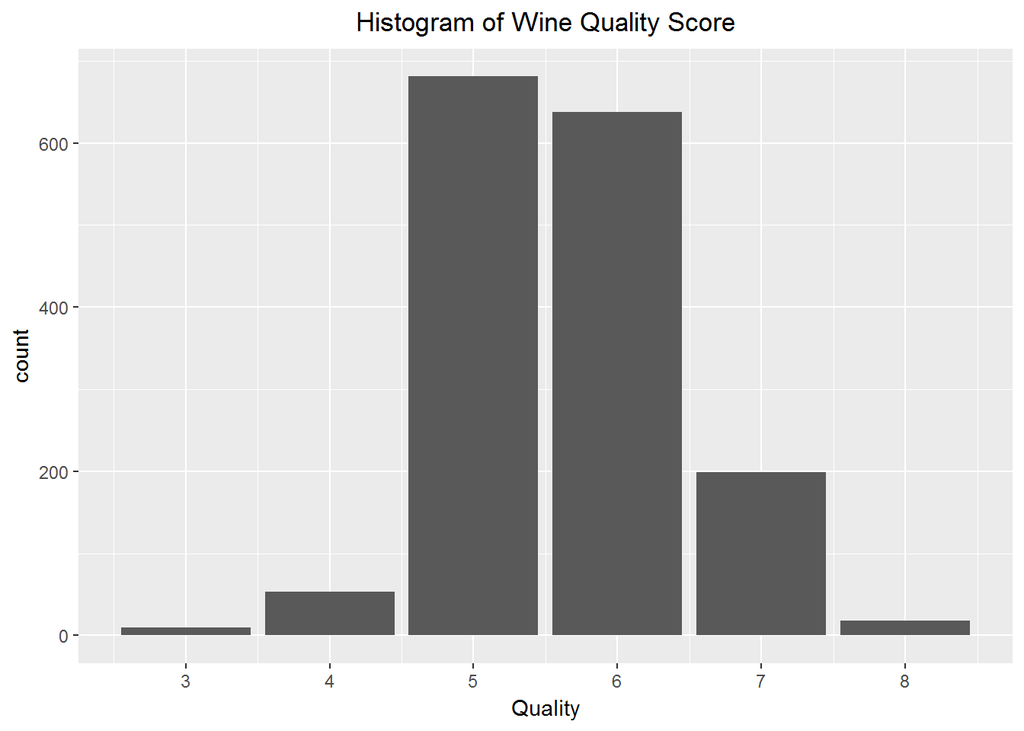

```
##    Min. 1st Qu.  Median    Mean 3rd Qu.    Max.
##   3.000   5.000   6.000   5.636   6.000   8.000
```

The wine quality score is spread between 3 and 8 with most of the scores at 5 and 6 for 1599 observations.

### Histogram of fixed acidity,volatile acidity,density and pH:

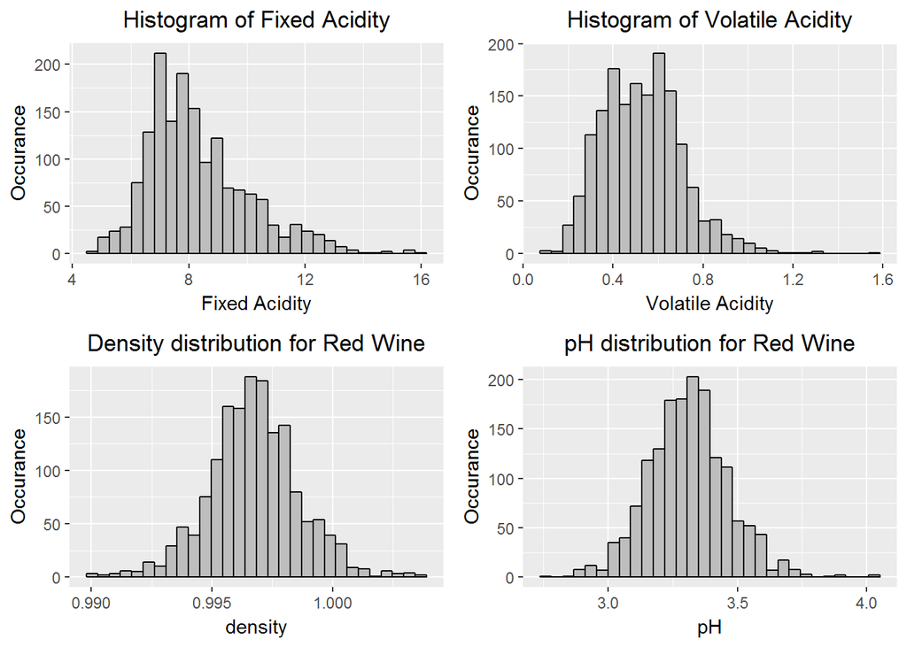

### Histogram of Citric acid:

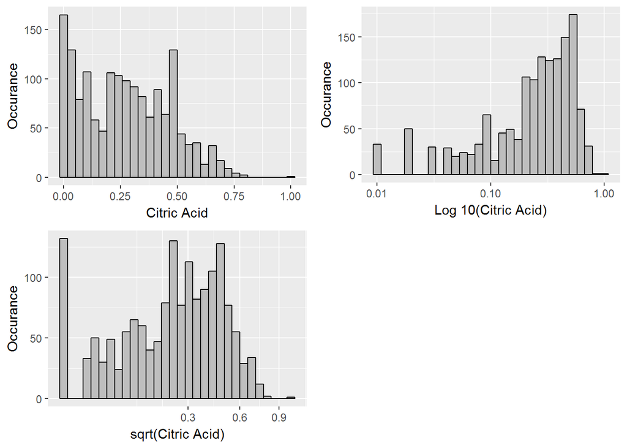

1)The histogram of citric acid is not normally distributed and we can see many values at point 0.

2)Using log transform did not helped much as it just resulted in left skew.

3)The square root transformation looks normally distributed but there are number of values at 0.

### Distribution analysis of Alcohol,Free SO2 and Total SO2,Residual sugar,

### chlorides and sulphates paramters across Red wine:

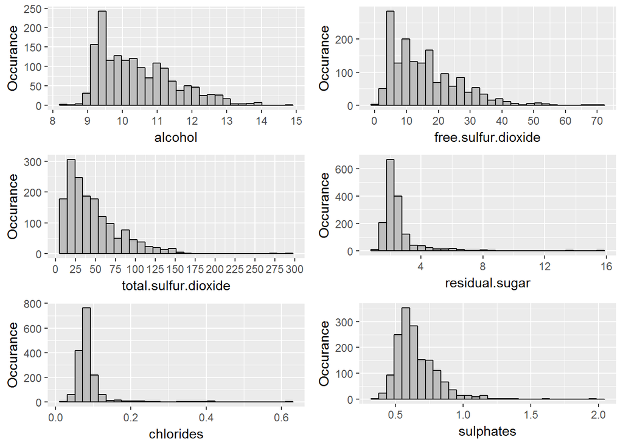

Observations:

The overall distributions of the six parameters considered here looks right skwed.

### Transforming data

Applying log10-transforamtion to parameters Alcohol,Free SO2 and Total SO2, Residual sugar,chlorides and sulphates using.

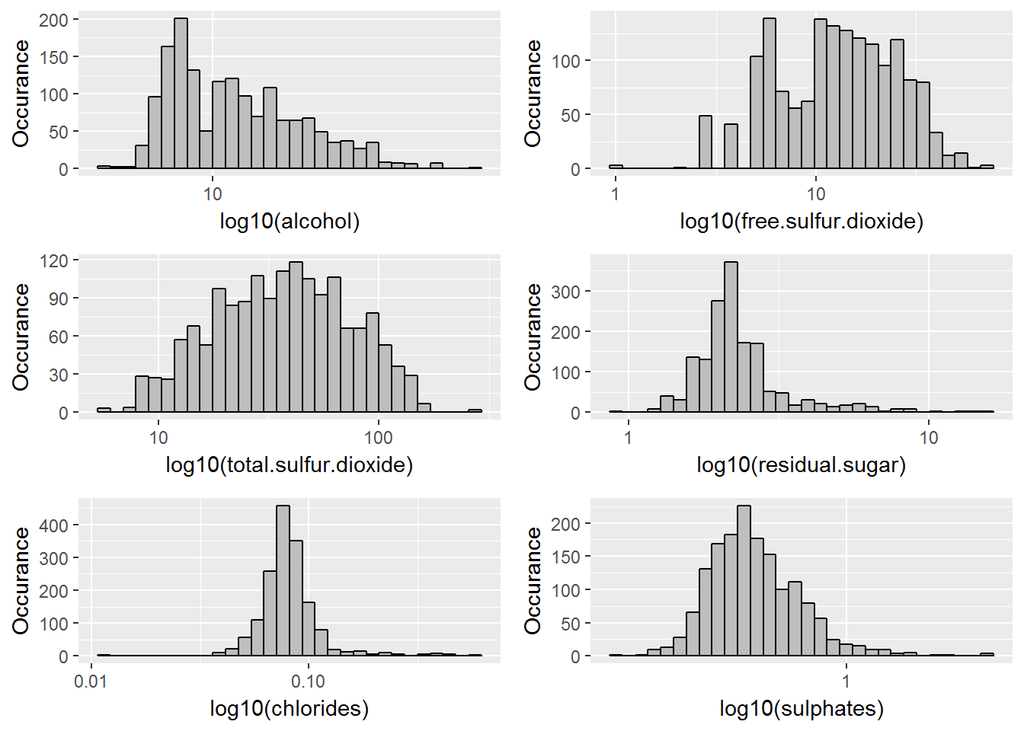

# Univariate Analysis

## What is/are the main feature(s) of interest in your dataset?

1)As most of the variables in the dataset have different chemical properties our main interest will be to understand which chemical properties influence the quality rating of the red wine.

2)Main interest will be on volatile acidity and citric acid as these relate to tase and freshness of the wine.

## What other features in the dataset do you think will help support your investigation into your feature(s) of interest?

Any other chemical variables could impact the quality rating. I think that having so many wines rated a 5 or 6 will make it challenging to put together a strong model.

## Did you create any new variables from existing variables in the dataset?

1)I have created a new column by dividing them into four categories based on pH value of the wine.(High,Moderately High,Medium,Low)

2)I created Another column quality rating based on quality variable which has three distinct categories: (bad: 3,4), (average: 5,6), (excellent: 7,8)

## Of the features you investigated, were there any unusual distributions? Did you perform any operations on the data to tidy, adjust, or change the form of the data? If so, why did

you do this?

Citric acid also had a noticeable right skew, but the log transformation simply made it into left skewed. The square root transformation resulted in a distribution that was closer to normal, except for the spike in zero values. Due to this pattern, I’m not sure this transformed variable will be useful.

# Bivariate Plot Section

### Correlation Matrix :

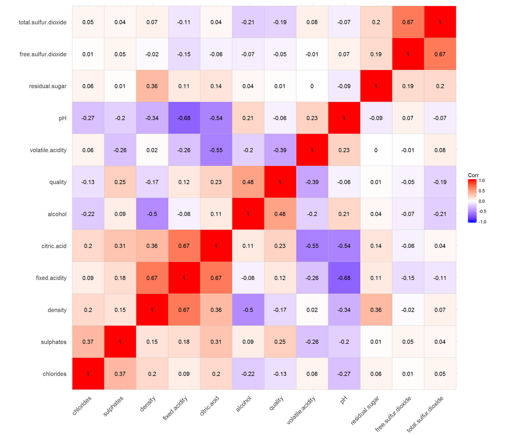

### ggpair plot:

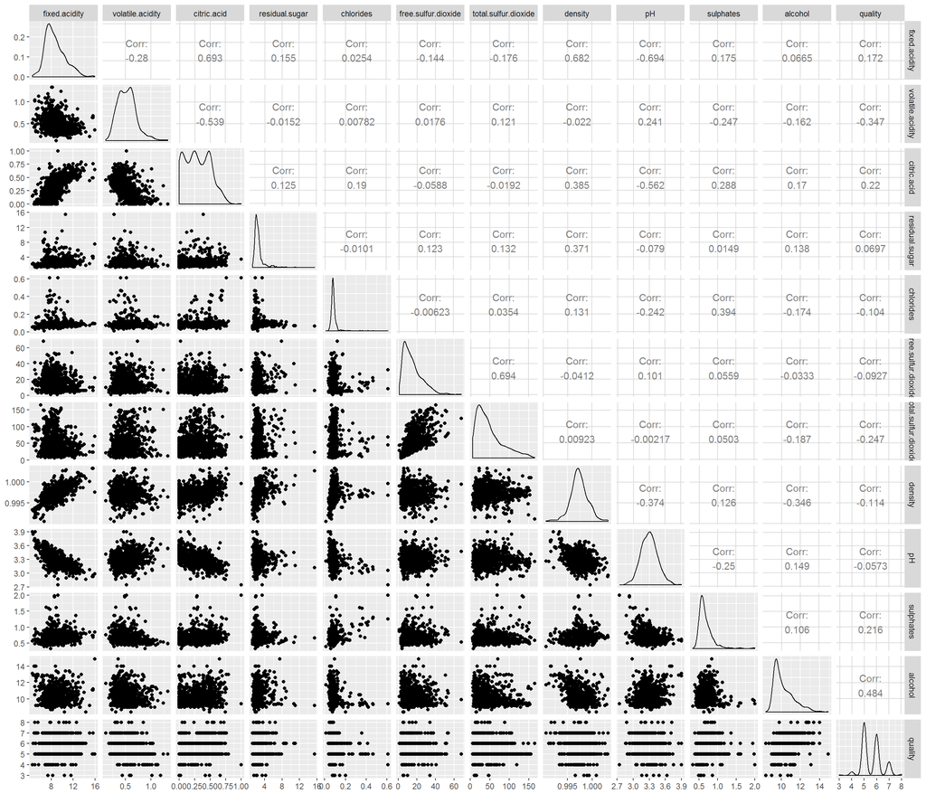

Correlation matrix and ggpair plot was used to have a glance at the data. We are interested the correlation between the wine quality and each chemical property.

## Let’s consider top four chemical components where wine quality increases together with increasing values of a characteristic’s variable.

1)Alcohol

2)Fixed acidity

3)Sulphates

4)Citric Acid

### The Box plot of wine quality rating vs Alcohol/FixedAcidity/Sulphates/Citric Acid:

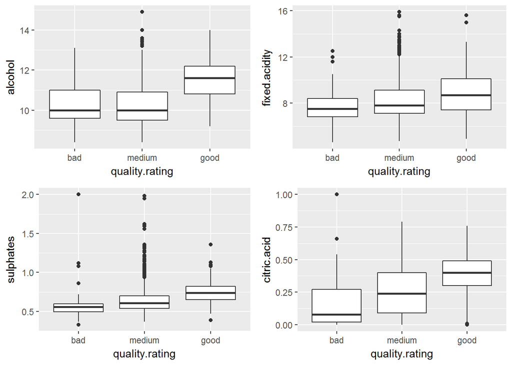

Alcohol content is significantly higher for excellent wines compared to bad or average wines.

## Let’s consider top four chemical components where wine quality decreases with increasing values of a characteristic’s variable.

### The Box plot of wine quality rating vs volatile.acidity/total sulfur dioxide/density/Chlorides:

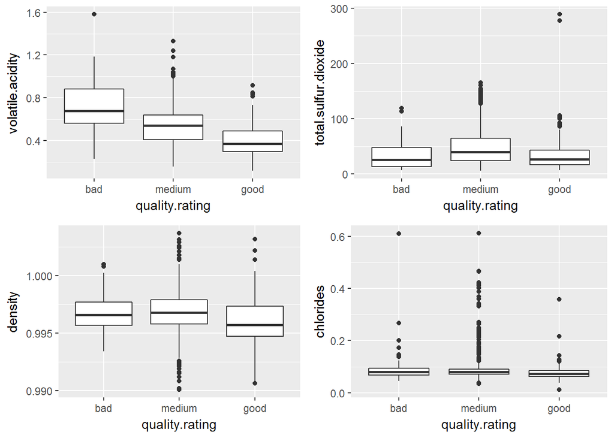

### The Box plot of wine quality rating vs pH

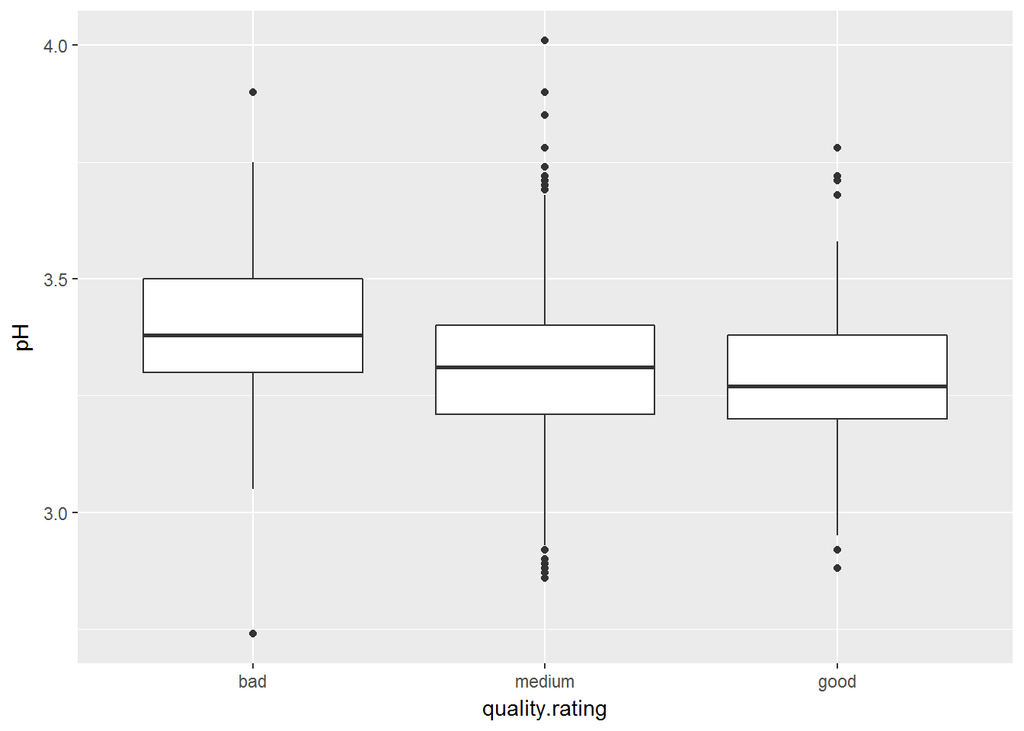

It looks like good quality wines have lesser pH.

### The Box plot of wine quality rating vs residual sugar:

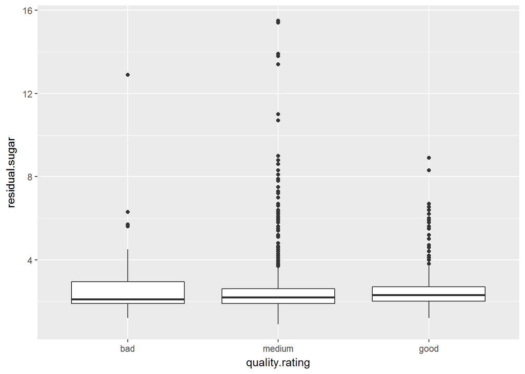

### correlation:

```
## [1] 0.01373164
```

Residual sugar has no significant relationship with quality.

### Scatter plot for Density VS Alcohol/Fixed Acidity:

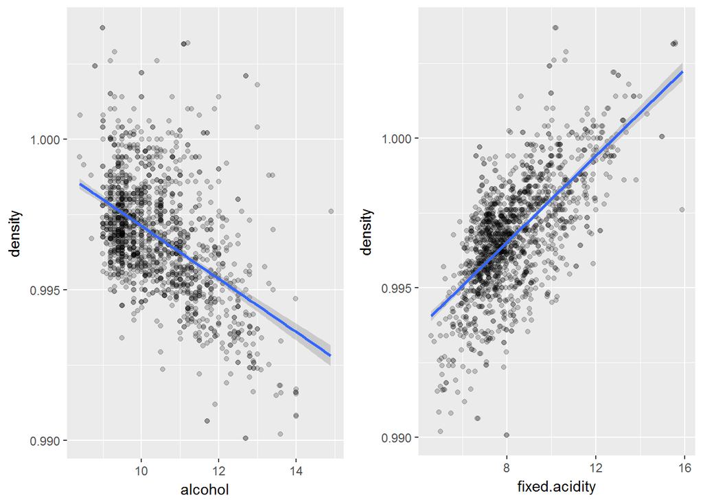

From Density vs Alcohol graph we can see that as higher the density the lower the percentage of alcohol.

### Scatterplot for fixed acidity VS citric acid :

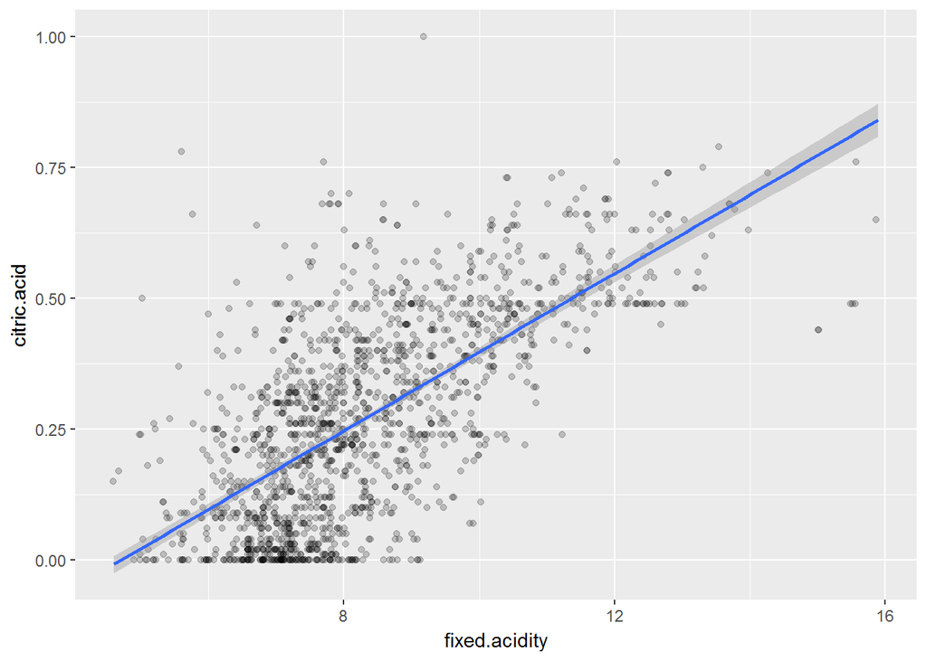

### Correlation between Fixed acidity and citric acid:

```
## [1] 0.6717034
```

Even the correlation between fixed acidiy and citric acid is positive and strong

### Scatterplot for volatile acidity acidity VS citric acid :

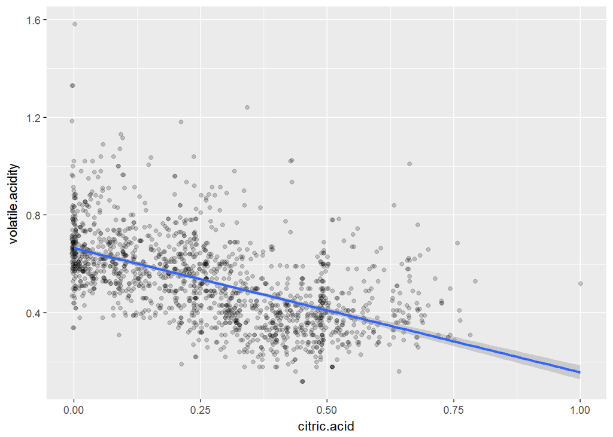

### Correlation between volatile acidity and citric acid:

```
## [1] -0.5524957
```

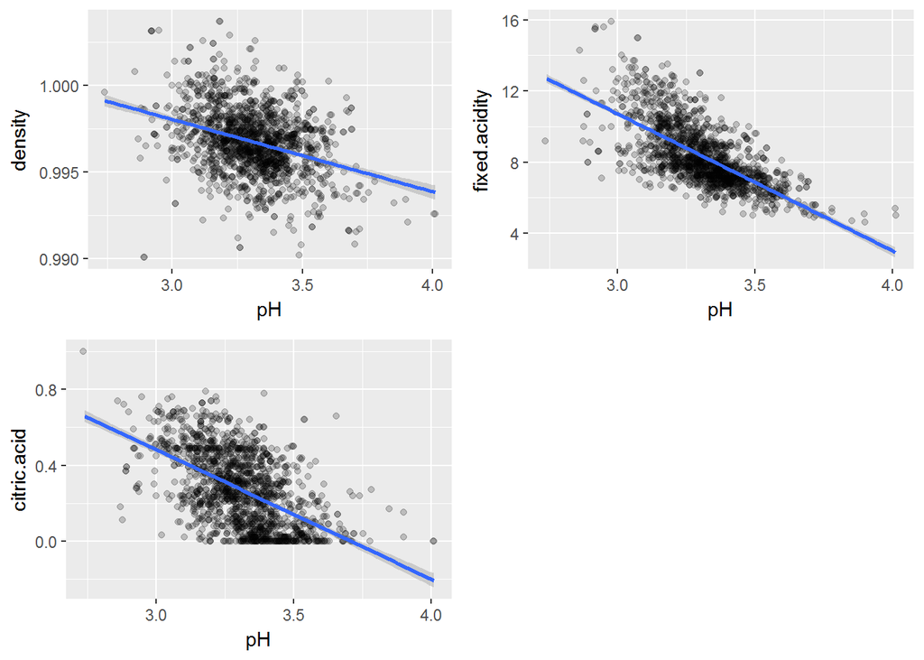

### Boxplot for Acidity level vs Alcohol:

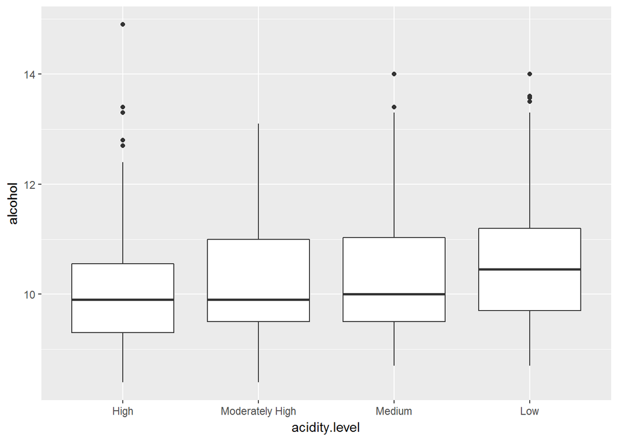

It can be seen that low acidity level has higher median percentage of alcohol content.

### Scatter plot for pH vs Alcohol

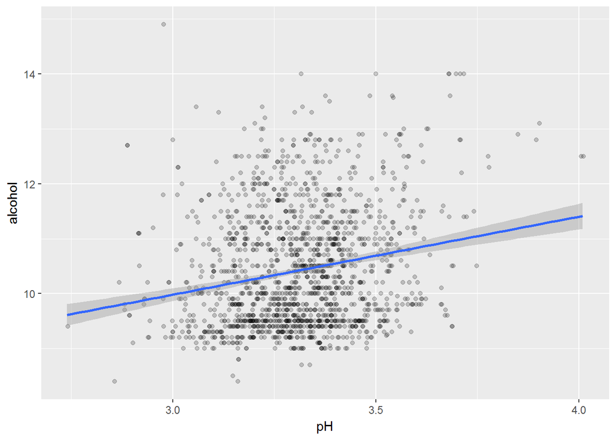

correlation :

```
## [1] 0.2056325
```

pH and alcohol have a positive correlation but very weakly correlated.

# Bivariate Analysis

## Talk about some of the relationships you observed in this part of the investigation. How did the feature(s) of interest vary with other features in the dataset?

I have made use of ggpairs and ggcorplot to get a better understanding of the relationships between various variables in the given data.

Here volatile acidity and citric acid are negatively correlated.It means fresher wines have less bitter taste of acitic acid.

Some of the top positive and negative correlations with quality include:

Positive Relationship :

1)Alcohol : 0.48

2)Fixed Acidity: 0.12

3)Sulphates : 0.25

4)Citric Acid : 0.23

Negative Relationship :

1)Volatile Acidity : -0.39

2)Total Sulfur dioxide : -0.19

3)Density : -0.17

4)Chlorides : -0.13

Some other interesting facts in the boxplots :

1)The lesser the pH value the better the quality of the wine.As the median value has decreased gradually from bad quality rating to good quality rating.

2)Citric acid which adds freshness to the wine has positive effect in wine as median increased from bad quality to good quality wines.

3)Though pH is less for good quality wines it doesn’t have a signifiacnt change in median value from bad wine to good wine.

## Did you observe any interesting relationships between the other features(not the main feature(s) of interest)?

1)Residual sugar has not a significant correlation coefficient with the quality.

2)pH vs fixed acidity,volatile acidity vs citric acid and pH vs citric acid were negatively correlated.

## What was the strongest relationship you found?

The strongest ralationship was between fixed acidity and pH which has correlation of -0.68.

# Multivariate Plots Section

### Quality VS Main Chemical Properties

From Bivariate analysis we have analyzed the variables which increases wine quality and the variables which decreases the wine quality.

Quality vs Alcohol based on color of voaltile acidity:

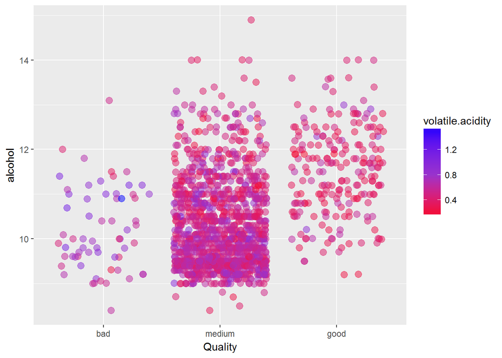

From the plot it is evident that high quality wines have less volatile acidity and high alcohol content.

Citric acid vs Volatile acidity based on Quality:

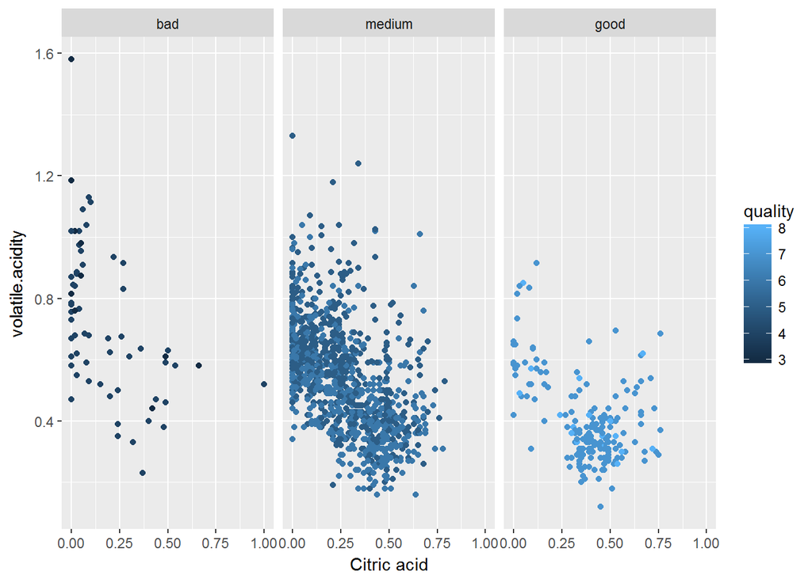

It is clear that good quality wines have less amount of volatile acidity and more amount of citric acid.

Alcohol vs Ph based on Quality

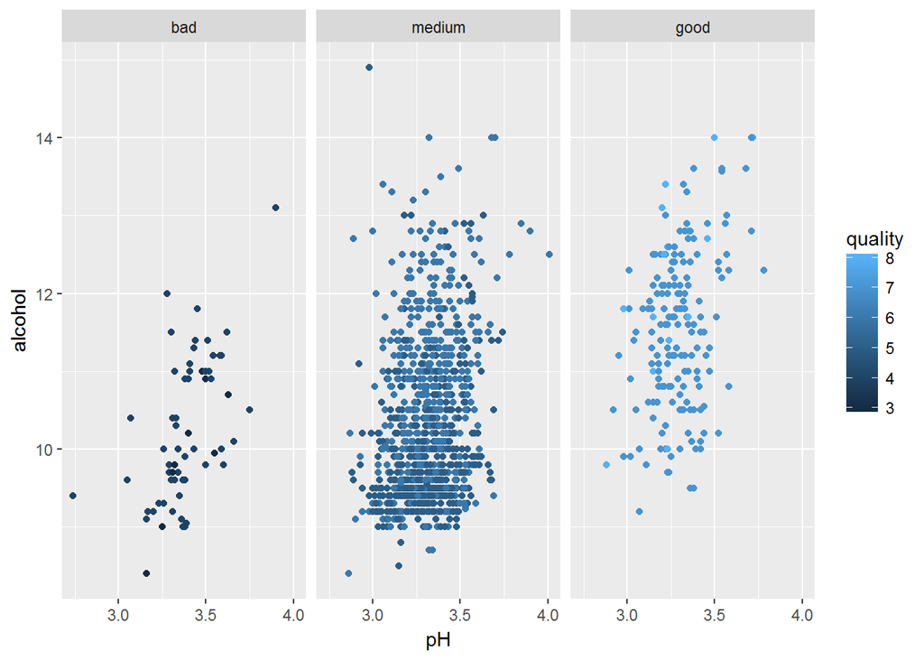

We can see that the pH value has not much effect on the quality of alcohol but better quality wines have more percentage of alcohol.

# Final Plots and Summary

## Plot 1 :

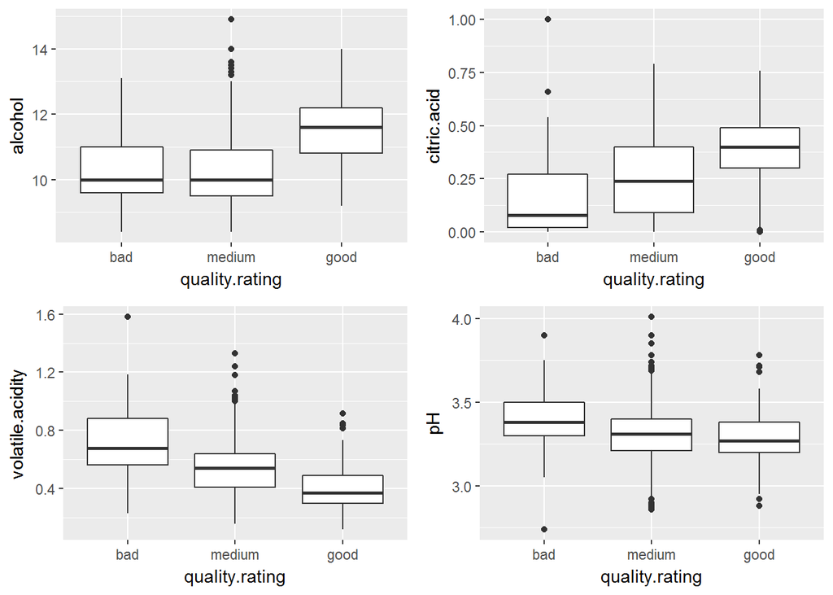

Description One :

From the box plot it is evident that as the percentage of alcohol and amount of citric acid increases the quality of wine increases.On contray increase in content of Vlatile acidity and pH decreases the quality of wine.

## Plot 2 : Alcohol and Quality

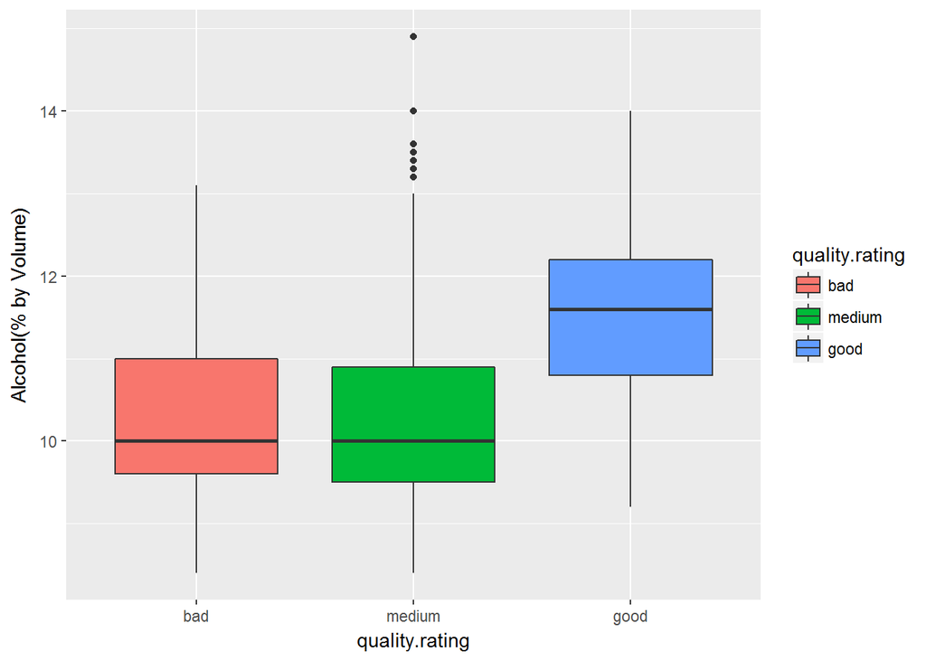

## Description Two :

This box plots shows how Good wines tend to have higher alcohol content while rest having almost equal amount of alcohol

## Polt 3 :

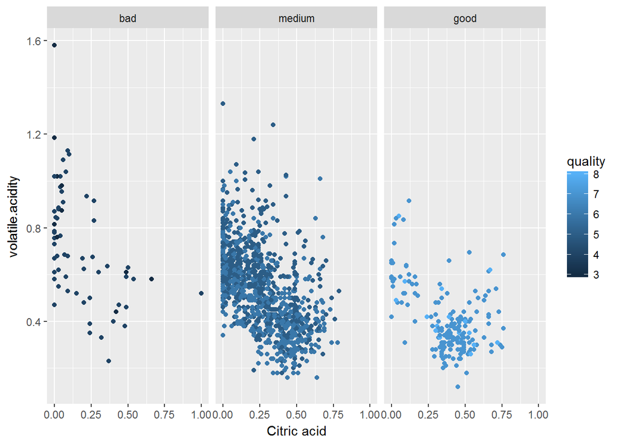

## Description Three :

This plot shows how quality is correlated with citric acid and volatile acidity. As Good quality wines have less volatile acidity and more citric acid.

# Reflection

The Red wine dataset has 1599 observations,13 variables which has 11 chemical properties.Here we are mainly interested in features which are correlated with quality.It is given that most wines are between 3-4 on the pH scale so it did not have much effect on quality.Alcohol content appeared to be the number one factor for determining an excellent wine.Volatile acidity essentially made a wine bad in large amounts,as large amounts of acetic acid create a bitter taste.WWhile plotting histograms of the chemical properties I have came across few plots which are not normally distributed and right skewed.As for linear and logistic regression we want to make sure that input and output variables is almost liner.For this purpose I have choosen log10 transformation on data as it affects the magnitude of the coefficient that corresponds to the logged variable, but it doesn’t affect the value of the outcome.Next I have created a column quality rating based on quality column.THe purpose of categorizing them into bad,average and good wines is to give an idea about the wine whether it a bad,average or good wine by just looking at the graph rather than confusing a end user to interpret which wines are of good quality whether rating 5,6,7 is average or 3,4,5 rating values are bad(In some datasets it maybe the case where 1 is good while 10 is bad).The graphs adequately illustrate the factors that make good wines ‘good’ and bad wines ’bad.

Some of the struggles I have faced is mainly adjusting the chemical property names on the figure as initially variables names are covered up and it looked difficult for end user to interpret out of the plot.Next thing is choosing the appropriate graph for a given context and to group together different plot’s of chemical properties so that it makes easy for a end user to get a brief overview by just seeing a couple of plot’s instead of plotting graphs seperately based on chemical properties.

Some limitation in the dataset is due to more data is based on quality ratings 5 and 6.Less data is provided on bad(3,4) and good(7,8) quality rating wines. If the data set almost equal amount number of observations based on individual quality rating then we can be more certain regarding the correlation between chemical components and the wine quality.I would like to improve more on adding colors and using different styles in the plot to make my project look more presentable.Next choosing different population of wine tasters which would help further strengthen similarities in the data.